# Ayudantía 5 - Regresión Multiple

Diego Bernal Soto: diego.bernals@mars_university.cl

# Capitulos de Futurama

[figure not shown]

Con el objetivo de entender mejor qué variables podrían influir en la clasificación de cada episodio, se realizo un scraping para obtener los scripts de los episodios, junto con información relevante como su nota en IMDb, número de votos y fecha de emisión.

A partir de la data, se busca realizar un análisis que permita **explorar** si la frecuencia de líneas de ciertos personajes (Bender), así como la mención de palabras clave (Bender), puede tener algún impacto en la valoración que los usuarios le dieron a cada episodio.

```r
#Required libraries

library(stargazer)
library(paqueteadp)
library(remotes)
library(ggcorrplot)
library(tidyverse)
library(cowplot) # dos o m?s gr?ficos uno al lado del otro
library(caret) # data partition
library(glmnet) # Ridge
library(car)
library(gghighlight)
library(rlang)
library(tidyverse)
library(tidymodels)
library(schrute)
library(lubridate)
library(knitr)
library("scales") #Paleta de colores de futurama
library(ggsci)
```

Nos traemos los datasets

```r
episode_list <- read.csv("./data/episode_list.csv", sep=";")
text_futurama <- read.csv("./data/only_spoken_text.csv", sep=",")
```

```r
glimpse(episode_list)
```

```
## Rows: 140
## Columns: 10
## $ Season            <int> 1, 1, 1, 1, 1, 1, 1, 1, 1, 1, 1, 1, 1, 2, 2, 2, 2, 2…
## $ Episode           <int> 1, 2, 3, 4, 5, 6, 7, 8, 9, 10, 11, 12, 13, 14, 15, 1…
## $ Episode.in.Season <int> 1, 2, 3, 4, 5, 6, 7, 8, 9, 10, 11, 12, 13, 1, 2, 3, …
## $ Title             <chr> "Space Pilot 3000", "The Series Has Landed", "I, Roo…
## $ Director.s.       <chr> "Rich Moore & Gregg Vanzo", "Peter Avanzino", "Bret …
## $ Writer.s.         <chr> "David X. Cohen & Matt Groening", "Ken Keeler", "Eri…
## $ Air.Date          <chr> "(1999-03-28)", "(1999-04-04)", "(1999-04-06)", "(19…
## $ Opening.Line      <chr> " In Color.", " In Hypno-Vision.", " As Seen On TV."…
## $ IMDBrating        <chr> "8.6", "8.0", "8.2", "8.1", "7.8", "8.2", "7.8", "8.…
## $ Votos             <chr> "4478", "3612", "3511", "3359", "3164", "3295", "311…
```

```r
glimpse(text_futurama)
```

```
## Rows: 23,812
## Columns: 4
## $ Season    <int> 1, 1, 1, 1, 1, 1, 1, 1, 1, 1, 1, 1, 1, 1, 1, 1, 1, 1, 1, 1, …
## $ Episode   <chr> "Space Pilot 3000", "Space Pilot 3000", "Space Pilot 3000", …
## $ Character <chr> "Fry", "Fry", "Boy", "Panucci", "Fry", "Michelle", "Fry", "B…
## $ Line      <chr> " Space. It seems to go on and on forever. But then you get …
```

## Limpieza de los datos

Tendremos que transformar la variable date, primero eliminando los parentesis y despues aplicando el formato de fecha exacta.

Tambien tendremos que limpiar los valores faltantes en nuestra variable objetivo que es el IMDB rating para cada episodio.

Por ultimo tendremos que formatear ciertas variables.

```r
futurama <- episode_list %>%
  mutate(Air.Date = ifelse(str_detect(Air.Date, "^\\(.*\\)$"), gsub("\\(|\\)", "", Air.Date), Air.Date),  # Eliminar par?ntesis si est? presente
         Air.Date = parse_date_time(Air.Date, c("%Y-%m-%d", "%B %d, %Y"))) %>%  filter(IMDBrating != "na") %>%
  mutate_at(vars(IMDBrating, Votos), as.numeric) %>% mutate(Season = factor(Season,as.character(1:7)))
```

Veamos la distibución de nuestra variable objetivo.

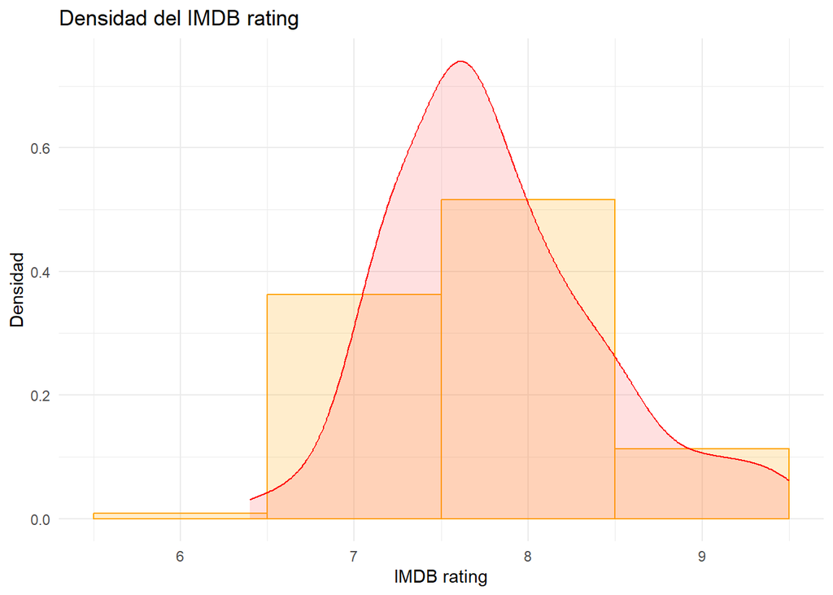

```r
pl0 <- ggplot(futurama, aes(x = IMDBrating)) +
  geom_histogram(aes(y = ..density..), colour = "orange", fill = "orange", alpha = 0.2, binwidth = 1)+
  geom_density(alpha = .2, fill = "#FF6666", colour = 'red') +
  theme_minimal() + labs(title = "Densidad del IMDB rating",
                         x="IMDB rating",
                         y="Densidad")

pl0
```

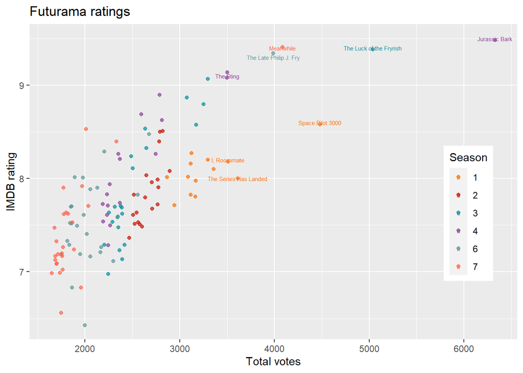

```r
pl1 <- ggplot(futurama, aes(x = Votos, y = IMDBrating, color = Season)) +
  geom_jitter(alpha = 0.7) +
  geom_text(data = subset(futurama, Votos >3500),
            aes(label = Title),
            size = 2,
            max.overlaps = 10
  ) +
  labs(
    title = "Futurama ratings",
    x = "Total votes",
    y = "IMDB rating",
    color = "Season"
  ) +
  theme(legend.position = c(0.9, 0.4)) + scale_color_futurama()
pl1
```

The luck of the frirysh one of the best ;D.

[figure not shown]

imagen episodio

Plotemos algunos boxplots para ver como se distribuyen nuestras variables en busqueda de ciertos outliers.

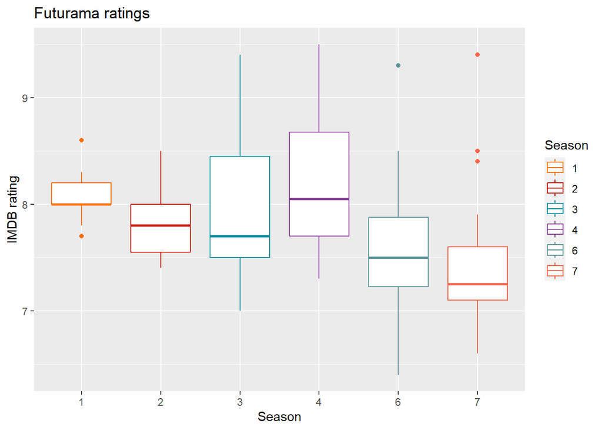

```r
pl2 <- ggplot(futurama,aes(x=Season,y=IMDBrating,color = Season)) +
  geom_boxplot() + labs(title = "Futurama ratings",
                        x = "Season",
                        y = "IMDB rating",
                        color = "Season"
  ) + scale_color_futurama()
pl2
```

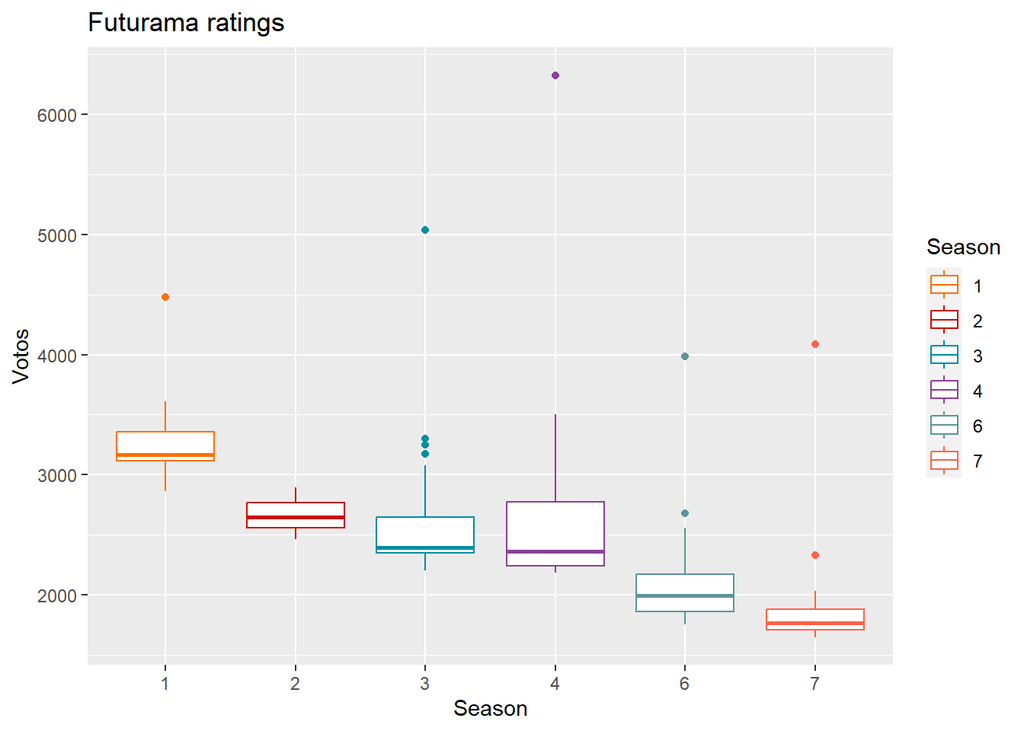

```r
pl3 <- ggplot(futurama,aes(x=Season,y=Votos,color = Season)) +
  geom_boxplot() + labs(title = "Futurama ratings",
                        x = "Season",
                        y = "Votos",
                        color = "Season"
  ) + scale_color_futurama()
pl3
```

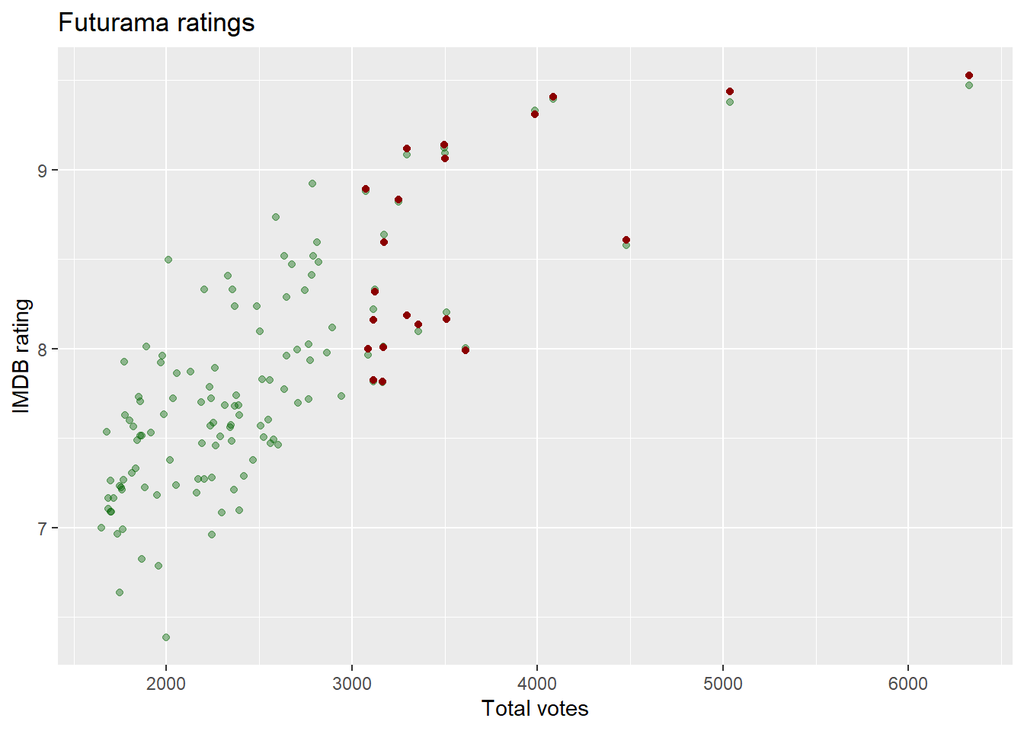

```r
pl4 <- ggplot(futurama, aes(x = Votos, y = IMDBrating)) +
  geom_jitter(col = "darkred")  +
  gghighlight(Votos > 3000, label_key = title, unhighlighted_colour = alpha("darkgreen", 0.4)) +
  labs(
    title = "Futurama ratings",
    x = "Total votes",
    y = "IMDB rating"
  )
pl4
```

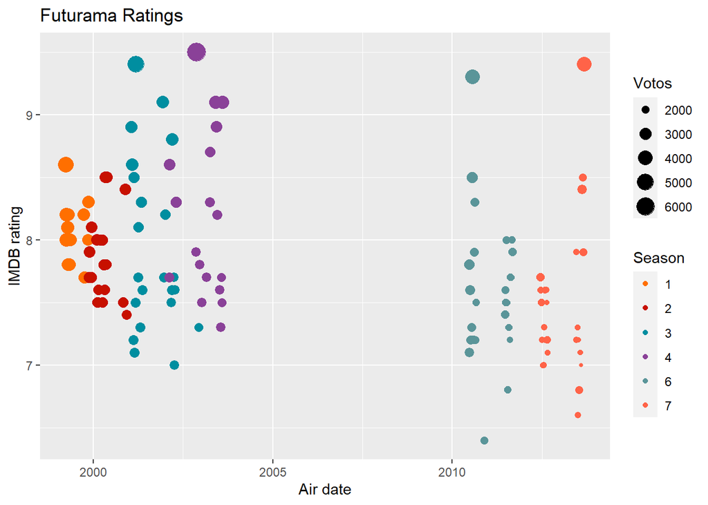

```r
pl5 <- ggplot(futurama,aes(x = Air.Date, y = IMDBrating,
                            color = Season, size = Votos)) +
  geom_point() +
  labs(x = "Air date", y = "IMDB rating",
       title = "Futurama Ratings")+ scale_color_futurama()
pl5
```

# Análisis de texto

```r
futurama<- futurama %>%
  rename(Episode_name = Title)

text_futurama <- text_futurama %>%
  rename(Episode_name = Episode)

text_futurama<- merge(text_futurama, futurama, by = "Episode_name")
glimpse(text_futurama)
```

```
## Rows: 20,381
## Columns: 13
## $ Episode_name      <chr> "A Bicyclops Built for Two", "A Bicyclops Built for …
## $ Season.x          <int> 2, 2, 2, 2, 2, 2, 2, 2, 2, 2, 2, 2, 2, 2, 2, 2, 2, 2…
## $ Character         <chr> "Leela", "Fry", "Leela", "Fry", "Leela", "Amy", "Ben…
## $ Line              <chr> " I know.", " You do?", " Fry, if it's obvious to yo…
## $ Season.y          <fct> 2, 2, 2, 2, 2, 2, 2, 2, 2, 2, 2, 2, 2, 2, 2, 2, 2, 2…
## $ Episode           <int> 22, 22, 22, 22, 22, 22, 22, 22, 22, 22, 22, 22, 22, …
## $ Episode.in.Season <int> 9, 9, 9, 9, 9, 9, 9, 9, 9, 9, 9, 9, 9, 9, 9, 9, 9, 9…
## $ Director.s.       <chr> "Susan Dietter", "Susan Dietter", "Susan Dietter", "…
## $ Writer.s.         <chr> "Eric Kaplan", "Eric Kaplan", "Eric Kaplan", "Eric K…
## $ Air.Date          <dttm> 2000-03-19, 2000-03-19, 2000-03-19, 2000-03-19, 200…
## $ Opening.Line      <chr> " This Episode Has Been Modified To Fit Your Primiti…
## $ IMDBrating        <dbl> 8, 8, 8, 8, 8, 8, 8, 8, 8, 8, 8, 8, 8, 8, 8, 8, 8, 8…
## $ Votos             <dbl> 2705, 2705, 2705, 2705, 2705, 2705, 2705, 2705, 2705…
```

```r
text_futurama %>%
  count(Character, sort = TRUE) %>% head(10) #Kif da igual
```

```
##     Character    n
## 1         Fry 3425
## 2      Bender 3046
## 3       Leela 2660
## 4  Farnsworth 1525
## 5    Zoidberg  773
## 6         Amy  750
## 7      Hermes  660
## 8        Zapp  419
## 9         Kif  217
## 10        Mom  142
```

```r
library(tidytext)
library(stm)
library(quanteda)
library(wordcloud)
library(reshape2)
library(geometry)
library(Rtsne)
library(rsvd)
library(syuzhet)
library(scales)
library(geniusr)
library(purrr)
library(jsonlite)
library(wordcloud2)
library(kableExtra)
library(textdata)
```

```r
text_futurama$Season <- factor(text_futurama$Season.x, levels = as.character(1:7))
```

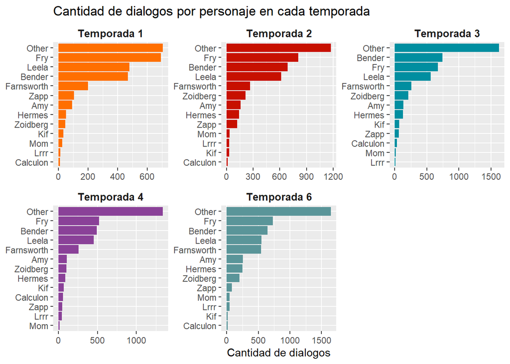

[figure not shown]

lrrr

```r
text_futurama %>%
  filter(!is.na(Line)) %>%
  mutate(
    character = fct_lump_n(Character, 12)
  ) %>%
  count(Season, character) %>%
  mutate(character = reorder_within(character, n, Season)) %>%
  ggplot(aes(n, character, fill = Season)) +
  geom_col(show.legend = FALSE) +
  facet_wrap(~Season, scales = "free", labeller = labeller(Season = function(x) paste("Temporada", x))) +
  scale_y_reordered() +
  scale_fill_futurama() +
  labs(x = "Cantidad de dialogos", y = NULL) +
  ggtitle("Cantidad de dialogos por personaje en cada temporada")+
  theme(strip.background = element_blank())+
  theme(strip.text = element_text(size = 10, face = "bold")) +
  labs(x = "Cantidad de dialogos", y = NULL) +
  labs(title = "Cantidad de dialogos por personaje en cada temporada")
```

```r
#Separando los dialogos en palabras.

text_futurama_1 <- text_futurama %>%
  mutate(Line = strsplit(Line, " ")) %>%
  unnest(cols = Line)
```

```r
#Separando los dialogos en palabras.

text_futurama_1 <- text_futurama %>%
  mutate(Line = strsplit(Line, " ")) %>%
  unnest(cols = Line)

text_futurama_1 <- text_futurama_1  %>%
  filter(Line != "" & Line != "...")
```

```r
data(stop_words)
```

```r
tidy_lines <- text_futurama_1 %>%
  unnest_tokens(word, Line) %>%
  anti_join(stop_words, by=c("word"="word"))


tidy_lines <- tidy_lines  %>% filter(word != "em", word != "y'all",word !="da",word != "ooh", word != "shit", word != "duh",
word != "na", word != "woah", word != "300",
word != "fi", word != "ba", word != "ugh",
word != "mm", word != "wah", word != "phi", word != "yeah", word != "mmh", word != "la", word != "uh", word != "ya", word != "ooh", word != "ayy", word != "i'ma", word != "mmm", word != "shit", word != "fuckin", word != "huh", word !="gon",word != "dem", word != "gwaan", word != "ey", word != "bam", word != "hey", word != "ah")
```

```r
word_freq <- tidy_lines %>%
  count(word) %>%
  arrange(desc(n))
```

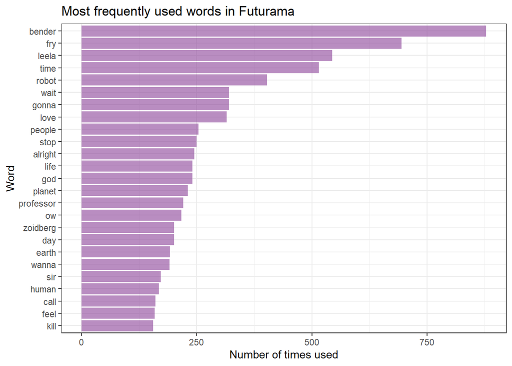

```r
top_25_words <- head(word_freq, 25)

p1 <- ggplot(top_25_words, aes(x = reorder(word, n), y = n)) +  # Utilizar reorder() para ordenar las barras de mayor a menor
  geom_bar(stat = "identity", fill = "#8A4198FF", alpha = 0.6) +
  coord_flip() +
  ylab("Number of times used") +xlab("Word")+
  theme_bw()+ ggtitle("Most frequently used words in Futurama")
p1
```

```r
text_futurama <- text_futurama %>%
  select(
    Episode_name,
    Character,
    Line,
    Season = Season.x,
    IMDBrating,
    Votos,
    Air.Date
  )
#Contar en que frases dijieron las palabras claves.
text_futurama <- text_futurama %>% mutate(
  Line = str_to_lower(Line),
  bender = if_else(str_detect(Line, "bender"),1,0),
  time = if_else(str_detect(Line,"time"),1,0),
  robot = if_else(str_detect(Line,"robot"),1,0),
  zoidberg = if_else(str_detect(Line,"zoidberg"),1,0)
)
```

```r
df_futurama <- text_futurama %>%
  group_by(Season,Episode_name,IMDBrating,Votos,Air.Date) %>%
  summarize(
    n_lines = n(),
    lines_fry = sum(Character == "Fry") / n_lines,
    lines_bender = sum(Character == "Bender") / n_lines,
    lines_leela = sum(Character == "Leela") / n_lines,
    lines_farnsworth = sum(Character == "Farnsworth") / n_lines,
    bender_mention = if_else(sum(bender==1)>=1,sum(bender)/n_lines,0),
    time_mention = if_else(sum(time==1)>=1,sum(time)/n_lines,0),
    robot_mention = if_else(sum(robot==1)>=1,sum(robot)/n_lines,0),
    zoidberg_mention = if_else(sum(zoidberg==1)>=1,sum(zoidberg)/n_lines,0),
    .groups = "drop"
  ) %>%
  select(-n_lines)
```

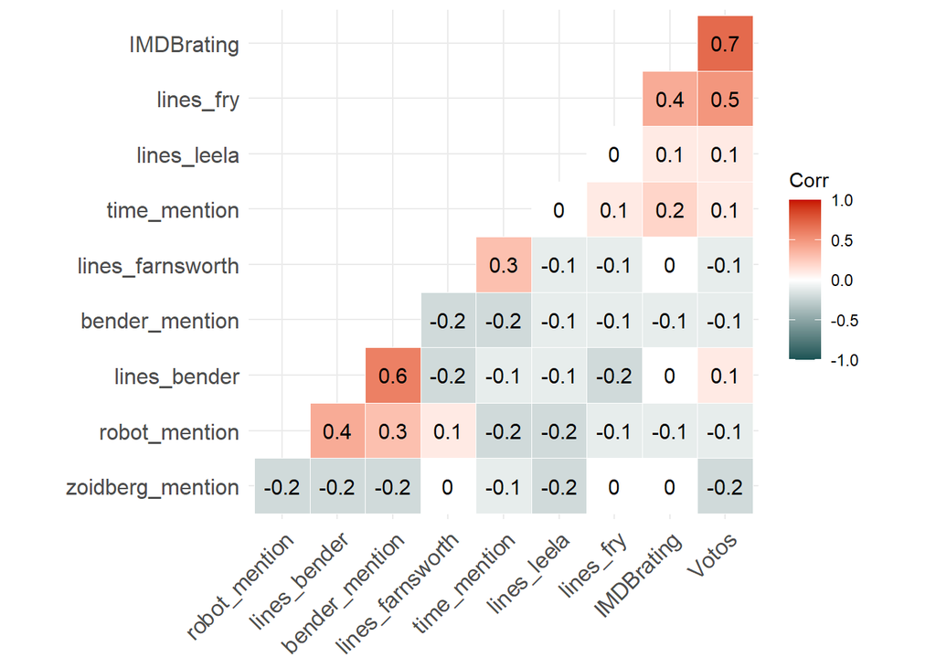

```r
corr_selected <- subset(df_futurama, select = c(IMDBrating,Votos,lines_fry,lines_bender,lines_leela,lines_farnsworth,
                                          bender_mention,time_mention,robot_mention,zoidberg_mention))

corr_matrix <- cor(corr_selected) %>%
  round(1)

graf_corr <- ggcorrplot(corr_matrix,
                   hc.order = TRUE,
                   type = "lower",
                   outline.color = "white",
                   colors = c("#1A5354FF", "white", "#C71000ff"),lab = TRUE)

graf_corr
```

```r
nzv <- nearZeroVar(df_futurama, saveMetrics= TRUE)
nzv
```

```
##                  freqRatio percentUnique zeroVar   nzv
## Season            1.136364      5.154639   FALSE FALSE
## Episode_name      1.000000    100.000000   FALSE FALSE
## IMDBrating        1.000000     26.804124   FALSE FALSE
## Votos             1.000000     95.876289   FALSE FALSE
## Air.Date          1.000000     97.938144   FALSE FALSE
## lines_fry         1.000000    100.000000   FALSE FALSE
## lines_bender      2.000000     98.969072   FALSE FALSE
## lines_leela       1.000000     97.938144   FALSE FALSE
## lines_farnsworth  1.500000     96.907216   FALSE FALSE
## bender_mention    1.000000     93.814433   FALSE FALSE
## time_mention      1.000000     91.752577   FALSE FALSE
## robot_mention    11.500000     75.257732   FALSE FALSE
## zoidberg_mention 11.666667     54.639175   FALSE FALSE
```

```r
nearZeroVar(df_futurama)#Mantenemos las mismas variables
```

```
## integer(0)
```

```r
set.seed(707) #Fijamos la semilla

fry <- initial_split(df_futurama)
fry_train <- training(fry)
fry_test <- testing(fry)
```

```r
mod_1 <- lm(IMDBrating~Season+Votos+lines_fry+lines_bender+lines_leela+lines_farnsworth+
              bender_mention+time_mention+robot_mention+zoidberg_mention,data=fry_train)

stargazer(mod_1, type = "html", align=TRUE)
```

|  | *Dependent variable:* |
| --- | --- |
|  | IMDBrating |
| Season | 0.085** |
|  | (0.037) |
| Votos | 0.001*** |
|  | (0.0001) |
| lines_fry | -0.576 |
|  | (0.630) |
| lines_bender | -1.155 |
|  | (0.880) |
| lines_leela | -0.570 |
|  | (0.738) |
| lines_farnsworth | -0.221 |
|  | (0.822) |
| bender_mention | 1.143 |
|  | (1.679) |
| time_mention | 2.228 |
|  | (2.168) |
| robot_mention | -0.787 |
|  | (1.842) |
| zoidberg_mention | 1.971 |
|  | (2.224) |
| Constant | 5.259*** |
|  | (0.409) |
| Observations | 72 |
| R<sup>2</sup> | 0.596 |
| Adjusted R<sup>2</sup> | 0.530 |
| Residual Std. Error | 0.368 (df = 61) |
| F Statistic | 9.011*** (df = 10; 61) |
| *Note:* | p<0.1; p<0.05; p<0.01 |

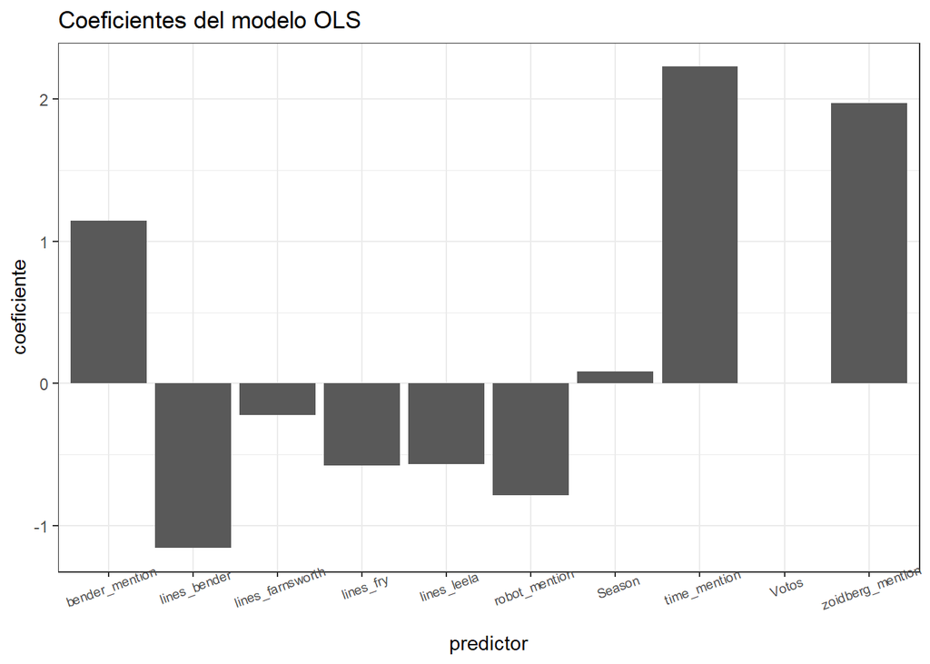

```r
futurama_coeficientes <- mod_1$coefficients %>%
  enframe(name = "predictor", value = "coeficiente")

futurama_coeficientes %>%
  filter(predictor != "(Intercept)") %>%
  ggplot(aes(x = predictor, y = coeficiente)) +
  geom_col() +
  labs(title = "Coeficientes del modelo OLS") +
  theme_bw() +
  theme(axis.text.x = element_text(size = 7, angle = 20))
```

[figure not shown]

```r
fry_train$pred <- mod_1$fitted.values
ggplot(fry_train, aes(x = Votos)) +
  geom_point(aes(y = IMDBrating, color = "Datos")) +
  geom_line(aes(y = pred, color = "Predichos")) +
  scale_color_manual(name = "Series", values = c("Datos" = "red", "Predichos" = "black")) +
  ggtitle("Regresión Multivariada") +
  xlab("Votos") +
  ylab("IMDB Rating")
```

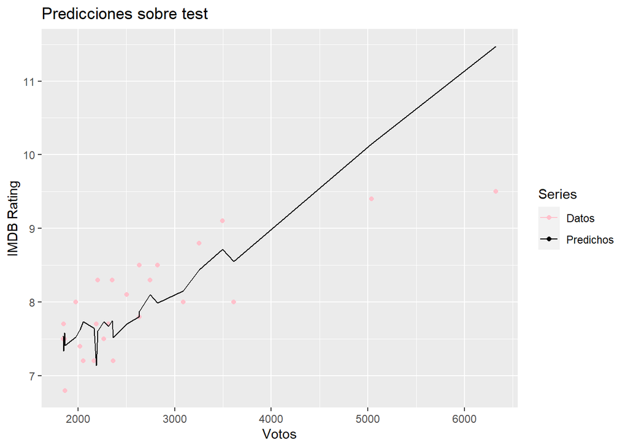

```r
fry_test$pred <- predict(mod_1, newdata = fry_test)
ggplot(fry_test, aes(x = Votos)) +
  geom_point(aes(y = IMDBrating, color = "Datos")) +
  geom_line(aes(y = pred, color = "Predichos")) +
  scale_color_manual(name = "Series", values = c("Datos" = "pink", "Predichos" = "black")) +
  ggtitle("Predicciones sobre test") +
  xlab("Votos") +
  ylab("IMDB Rating")
```

## Significancia de variables y del modelo.

### Significancia global

Para evaluar significancia global, realizamos una descomposición de varianza.

1. $SST=\sum_{i=1}^{N}{(y_i-\bar{y})^2\ \ }$ **Varianza total**
2. $SSR=\sum_{i=1}^{N}{(\widehat{y_i}-\bar{y})^2\ \ }$ **Variabilidad de la regresión**
3. $SSE=\sum_{i=1}^{N}{\widehat{(u_i})^2\ \ }$ **Variabilidad del residuo**
4. Se cumple que $SST=SSR+SSE$

Por lo que para evaluar significancia global, se plantea la siguiente hipotesis.

- $H_0;\ B_i=0,\forall_i=1...K$
- $H_a;\ B_i\neq0$

El estadístico de prueba es;

- $F=\frac{\left(\frac{SSR}{K}\right)}{\left(\frac{SSE}{N-K-1}\right)} | F_{(K;N-k-1)}$

Este valor se refiere al test de hipotesís con $H_0$ igual a que todos los coeficientes del modelo tengan el valor de 0, el criterio mas utilizado y de mas facil interpretación es ver el valor del p-value que te otorgan los software relacionados con este test y comparas con el nivel de significancia que estableciste como evaluador, en *R* es común que aparezcan asteriscos al lado de este calculo en los summary estos representan si es significativo el estadistico.

### Significancia individual

Para evaluar significancia individual para cada variable se plantea la siguiente hipótesis:

- $H_0;\ B_k=0$
- $H_a;\ B_k\neq0$

El estadístico a utilizar es t.

- $T=\frac{B_k}{SE({\hat{B}}_k)} | t_{(\alpha;N-K-1)}$

Este valor se refiere al test de hipotesís con $H_0$ iagual a que este coeficiente en especifico no aporte información al modelo o su valor sea cercano a 0. Se recomienda observar el p-value que entregue el software.

# Diagnostico de residuos.

*Supuestos*

1. los residuos $u_i$ tienen distribución normal.
2. los residuos $u_i$ tienen media cero.
3. los residuos $u_i$ tienen varianza constante.
4. los residuos $u_i$ no estan correlacionados.

## Residuos

Los residuos en los modelos nos ayudan a; determinar que tan bien el modelo explica el patrón de los datos, verificar los supuestos del modelo.

- $e_i=y_i-\hat{y_i}$

## Normalidad en los errores.

```r
#Definimos la variable res_b la cual contiene los residuales del modelo planteado.
res_b <- rstandard(mod_1)

#Shapiro-Wilk

#En el caso de este test la hipotesis nula es que los residuos presentan una distribución normal, con un(p-value<0.05), nos indica que se debe rechazar la hipótesis nula, los residuos no presentan una distribución normal.

shapiro.test(res_b)
```

```
##
##  Shapiro-Wilk normality test
##
## data:  res_b
## W = 0.96979, p-value = 0.0806
```

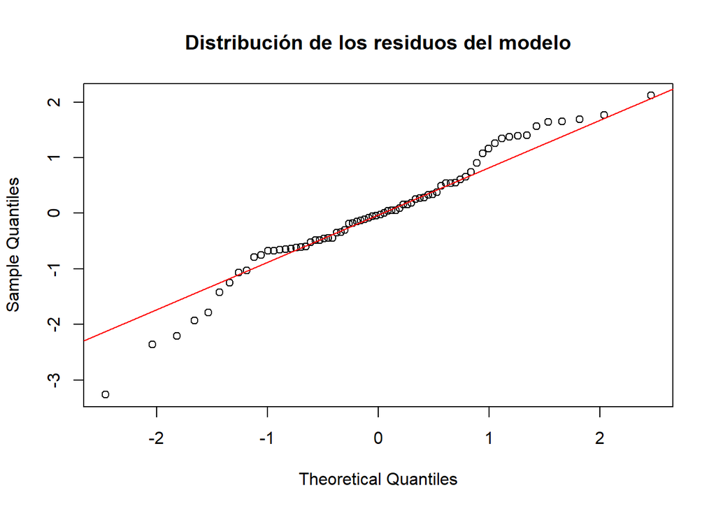

```r
#Graficamente
qqnorm(res_b,main = "Distribución de los residuos del modelo")
qqline(res_b,col="red")
```

Para que se cumpla el supuesto de normalidad de los errores se necesita que esten lo mas alineados con la recta de referencia, alejamientos severos de esta recta representarian la no normalidad.

## Residuos con media 0.

Simplemente calculamos la media de los residuos.

```r
res_a <- resid(mod_1)
mean(res_a)
```

```
## [1] -9.681022e-18
```

Como podemos observar este valor es 0, por lo que se cumple este supuesto.

## Resumen de Graficos sobre los residuos

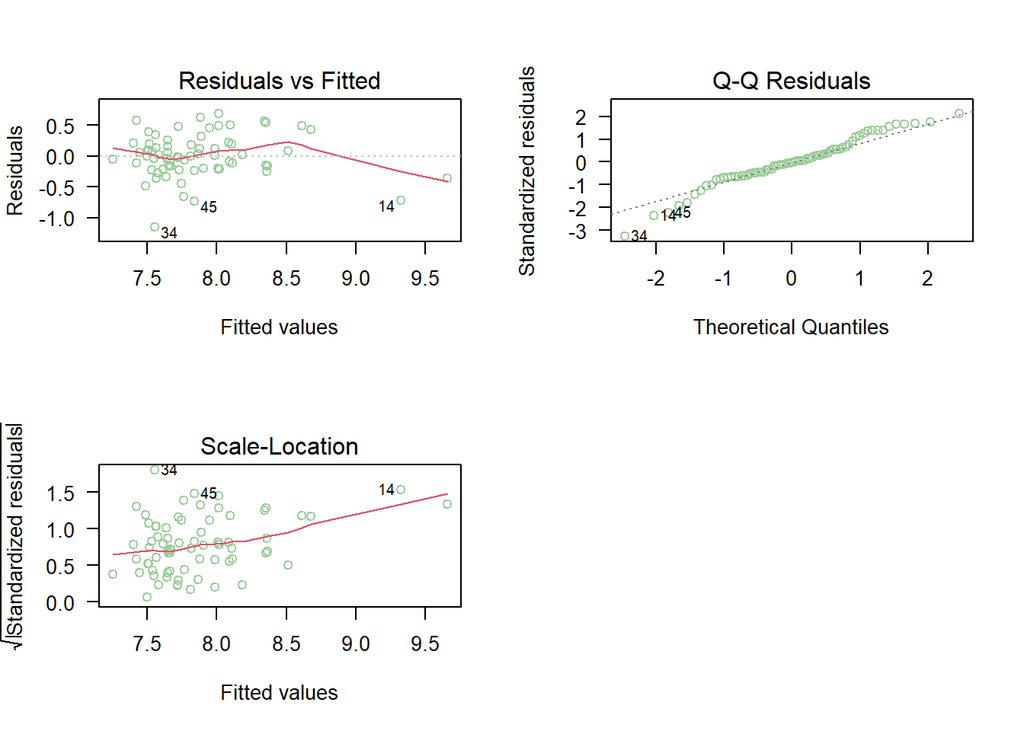

```r
par(mfrow=c(2, 2))
plot(mod_1, las=1, col='darkseagreen3', which=1:3)
```